# Bayesian regression

```python
import numpy as np
from scipy.stats import multivariate_normal
import matplotlib.pyplot as plt
import seaborn as sns
sns.set_theme()
```

## Question 1

> Write a function `phi(x)` that returns $\Phi_x$ for `x=`$(x_1, \dots, x_n)$.

```python
n= 20        # Sample size
alpha = .1  # Prior precision
beta = 5.  # Noise precision
```

```python
def phi(x): #x is a random vector iid of uniform law between 0 and 2pi
    n = len(x)
    phi_x = np.zeros((n, 2))
    phi_x[:, 0] = np.sin(x)
    phi_x[:, 1] = 1
    return phi_x
```

```python
data = 2*np.pi*np.random.rand(n)
Phi = phi(data)  # Design matrix
```

## Question 2

> Sample $y$ according to the Bayesian model described previously. Plot the on the same figure:
> 1. the graph of the function $x' \in [0, 2\pi] \mapsto \phi(x')w$;
> 2. the observations $y_1, \dots, y_n$ against $x_1, \dots, x_n$.

```python
w = multivariate_normal.rvs(cov=np.eye(2)/alpha)  # True parameter car 2 colonne dans le phi
Y = Phi@w + multivariate_normal.rvs(cov=np.eye(n)/beta)
```

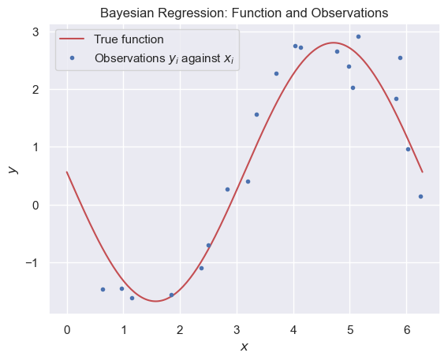

```python
#Plot

x = np.linspace(0, 2*np.pi, num=200)

plt.plot(x, phi(x)@w, 'r', label='True function')
plt.plot(data, Y, '.', label='Observations $y_i$ against $x_i$')
plt.xlabel('$x$')
plt.ylabel('$y$')
plt.legend()
plt.title('Bayesian Regression: Function and Observations')
ylim = plt.ylim()
plt.show()
```

## Question 3

> Compute the Bayesian estimator/predictor $x_{\mathrm{new}} \mapsto \hat{y}^{\mathcal{D}}(x_{\mathrm{new}})$.

```python
# Posterior distribution of w given the observed data
Sigma_posterior = np.linalg.inv(alpha*np.eye(Phi.shape[1]) + beta*Phi.T@Phi)  # Posterior covariance
mean_posterior = Sigma_posterior @ (Phi.T @ Y) * beta

# Bayesian estimator for a new input x_new
y_new_estimator = phi(x)@ mean_posterior
```

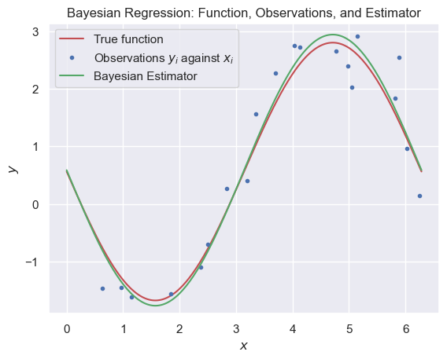

```python
# True function
plt.plot(x, phi(x)@w, 'r', label='True function')

# Observations
plt.plot(data, Y, '.', label='Observations $y_i$ against $x_i$')

# Bayesian estimator
plt.plot(x, y_new_estimator, 'g', label='Bayesian Estimator')

plt.xlabel('$x$')
plt.ylabel('$y$')
plt.ylim(ylim)
plt.legend()
plt.title('Bayesian Regression: Function, Observations, and Estimator')
plt.show()
```

## Question 4

> Compute the standard deviation $\sigma_N(x_\text{new})$ of $y_\text{new} | x_\text{new}$ and illustrate the predictive uncertainty by plotting a shaded region, that spans $\sigma_N(x')$ either side of $\hat{y}^{\mathcal{D}}(x')$.

[figure not shown]

```python
# Answer

# Compute the standard deviation of the predictive distribution for a new input x_new
variance_predictive = 1/beta +np.diag(phi(x)@Sigma_posterior@phi(x).T)
std_dev_predictive = np.sqrt(variance_predictive)

# Plot the results with shaded uncertainty region

# Bayesian estimator
plt.plot(x, y_new_estimator, 'g', label='Bayesian Estimator')

#Shaded region
plt.fill_between(x, y_new_estimator - std_dev_predictive,
                 y_new_estimator + std_dev_predictive, color='g', alpha=0.2, label='95% Predictive Interval')

# True function
plt.plot(x, phi(x)@w, 'r', label='True function')

# Observations
plt.plot(data, Y, '.', label='Observations $y_i$ against $x_i$')

plt.xlabel('$x$')
plt.ylabel('$y$')
plt.ylim(ylim)
plt.legend()
plt.title('Bayesian Regression: Function, Observations, and Estimator with Uncertainty')
plt.show()
```

## Homework

> Suppose we want to address the previous problem with polynomial regression from data generated from the cell:

```python
# Answer
n = 30  # Sample size
alpha = .1  # Prior precision
beta = 5.  # Noise precision

X = 2*np.pi*np.random.rand(n)  # Design matrix
Phi = phi(X)
w = multivariate_normal.rvs(cov=np.eye(2)/alpha)  # True parameter
Y = Phi@w + multivariate_normal.rvs(cov=np.eye(n)/beta)
```

# Question for the homework:

> Based on the data that are generated from the previous cell, determine an adequate degree for polynomial regression based on Bayesian hyper-parameter selection (or model selection). Recall that under uniform prior, it boils down to maximizing the marginal likelihood.

```python
def polynomial(x,d): #x is a random vector iid of uniform law between 0 and 2pi of size n
    n = len(x)
    phi_x = np.zeros((n, d+1))
    for j in range(d+1):
        phi_x[:,j]= x**j
    return phi_x

def posterior(X, Y, d):
    Phi = polynomial(X, d)
    Sigma_posterior = np.linalg.inv(alpha*np.eye(Phi.shape[1]) + beta*Phi.T@Phi)  # Posterior covariance
    mean_posterior = Sigma_posterior @ (Phi.T @ Y) * beta     #Posterior mean
    return mean_posterior, Sigma_posterior

def log_marginal_likelihood(X,Y,d):
    Phi = polynomial(X, d)
    posterior_mean, posterior_variance = posterior(X, Y, d)

    #cst = np.log(alpha)*(d)/2 + (np.log(beta) - np.log(2*np.pi))*(n/2) + np.log(np.linalg.det(posterior_variance))/2

    cst = (     np.log(alpha) * (Phi.shape[1]) / 2 + (np.log(beta) - np.log(2 * np.pi)) * (Phi.shape[0] / 2)
              + np.log(np.linalg.det(posterior_variance) + 1e-10) / 2    )

    lml = cst - (0.5*beta*(np.linalg.norm(Y-Phi@posterior_mean,2)**2)
                + 0.5*alpha*(np.linalg.norm(posterior_mean)**2))

    return lml
```

**The goal is to maximize the log marginal likelihood, and the degree d that maximizes this quantity can be considered the most suitable for the polynomial regression.**

```
The best model is for degree = 3
```

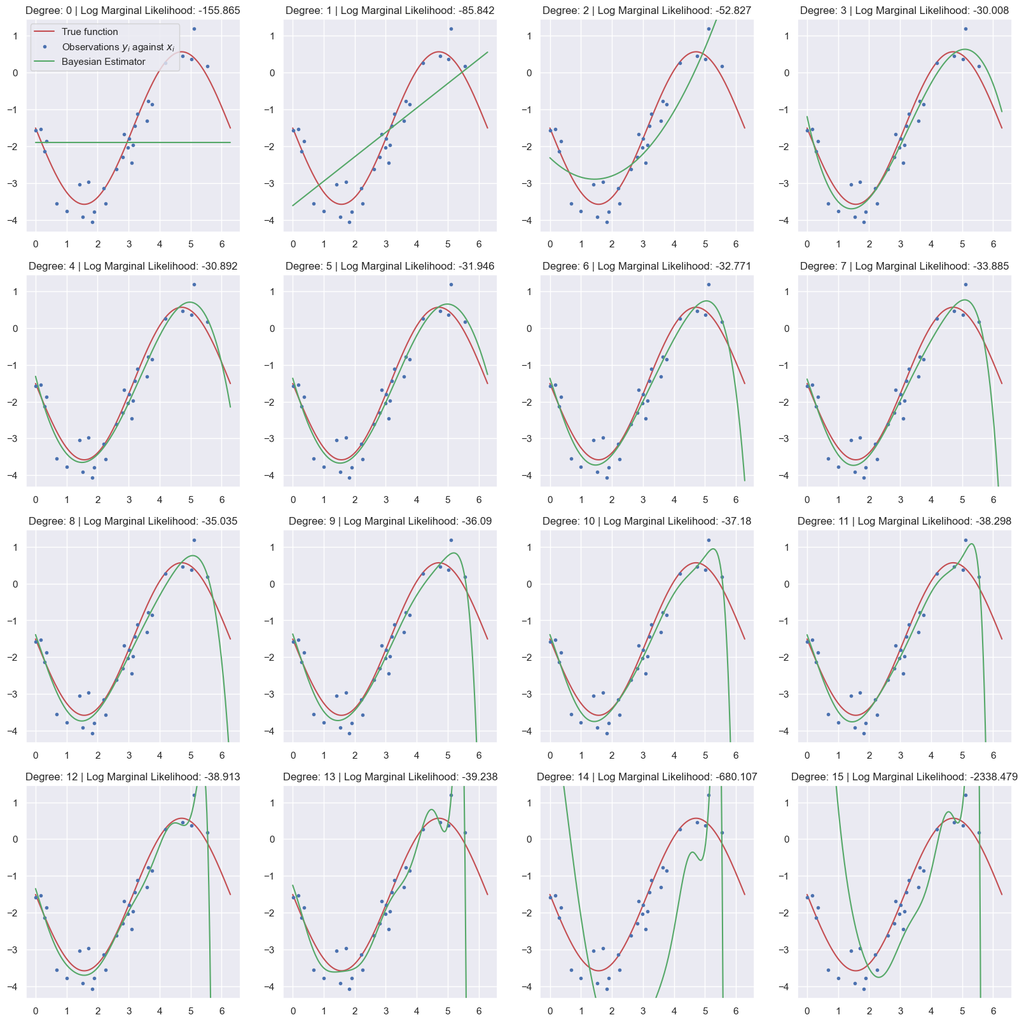

```python
result = []  # List of (degree, log_marginal_likelihood)

#Creat a 4x4 grid of subplots
fig, axes = plt.subplots(4, 4, figsize=(20,)*2)
for d, ax in enumerate(axes.flat):

    mean_posterior, sigma_posterior = posterior(X, Y, d)
    estimateur = polynomial(x, d) @ mean_posterior  # Estimated function

    lml = log_marginal_likelihood(X,Y,d)
    result.append([d , lml])


    # PLot
    ax.plot(x, phi(x)@w, 'r', label='True function')
    ax.plot(X, Y, '.', label='Observations $y_i$ against $x_i$')
    ax.plot(x, estimateur, 'g', label='Bayesian Estimator')
    ax.set_title("Degree: " + str(d) + " | Log Marginal Likelihood: " + str(round(lml, 3)))

    #Legend
    if d==0:
        ax.legend()
        ylim = ax.get_ylim()
    ax.set_ylim(ylim)


max_d = 0
max_lml = result[0][1]
for i in range(1,len(result)):
    if result[i][1] > max_lml:
        max_d = i
        max_lml = result[i][1]


print('The best model is for degree =', max_d)
```